# Neural Network with [Kera](https://keras.io/losses/)

Keras is a high-level neural networks API, written in Python and capable of running on top of TensorFlow, CNTK, or Theano. It was developed with a focus on enabling fast experimentation. Being able to go from idea to result with the least possible delay is key to doing good research.

Use Keras if you need a deep learning library that:

- Allows for easy and fast prototyping (through user friendliness, modularity, and extensibility).
- Supports both convolutional networks and recurrent networks, as well as combinations of the two.
- Runs seamlessly on CPU and GPU.

# Sieć neuronowa do klasyfikacji binarnej

## Dataset: Parkinsons Disease

**Oxford Parkinson's Disease Detection Dataset**

Ten zestaw danych składa się z szeregu biomedycznych pomiarów od 31 osób, 23 z chorobą Parkinsona (PD). Każda kolumna w tabeli to konkretna miara głosu, a każdy wiersz odpowiada jednemu z 195 głosów nagrań (kolumna „nazwa”). Głównym celem danych to odróżnienie zdrowych ludzi od osób z PD, zgodnie z „statusem” kolumna, która jest ustawiona na 0 dla zdrowych i 1 dla PD.

Dane są w formacie ASCII CSV. Wiersze pliku CSV zawierają instancja odpowiadająca jednemu nagraniu głosowemu. Jest około sześć nagrań na pacjenta, nazwisko pacjenta jest identyfikowane w pierwszej kolumnie. W celu uzyskania dalszych informacji lub przekazania uwag prosimy o kontakt z Max Little (mały „@” robots.ox.ac.uk).

Attribute Information:

Matrix column entries (attributes):

- name - nazwa podmiotu i numer nagrania w ASCII
- MDVP:Fo(Hz) - Average vocal podstawowa głosu
- MDVP:Fhi(Hz) - Maximum vocal podstawowa głosu
- MDVP:Flo(Hz) - Minimum vocal podstawowa głosu
- MDVP:Jitter(%),MDVP:Jitter(Abs),MDVP:RAP,MDVP:PPQ,Jitter:DDP - Kilka miar zmienności częstotliwości podstawowej
- MDVP:Shimmer,MDVP:Shimmer(dB),Shimmer:APQ3,Shimmer:APQ5,MDVP:APQ,Shimmer:DDA - Kilka miar zmienności amplitudy
- NHR,HNR - Dwie miary stosunku szumu do składników tonalnych w głosie
- status - Health status of the subject (one) - Parkinson's, (zero) - healthy
- RPDE,D2 - Dwie nieliniowe miary dynamiki złożoności
- DFA - Wykładnik skalowania fraktali sygnałowej
- spread1,spread2,PPE - Trzy nieliniowe miary podstawowej zmiany częstotliwości

dataset: https://archive.ics.uci.edu/ml/machine-learning-databases/parkinsons/parkinsons.data

#### Imports

```python
###################################################################################
#Import numpy - Moduł Numpy jest podstawowym zestawem narzędzi dla
#języka Python umożliwiającym zaawansowane obliczenia matematyczne,
#w szczególności do zastosowań naukowych (tzw. obliczenia numeryczne,
#jak mnożenie i dodawanie macierzy, diagonalizacja czy odwrócenie,
#całkowanie, rozwiązywanie równań, itd.). Daje on nam do dyspozycji
#specjalizowane typy danych, operacje i funkcje, których nie ma w typowej
#instalacji Pythona. Natomiast moduł Scipy pozwala na dostęp do bardziej
#złożonych i różnorodnych algorytmów wykorzystujących bazę zdefiniowaną w Numpy.
###################################################################################
import numpy as np

###################################################################################
#Import pandas - Biblioteka, która pozwala na wczytywanie danych do tabeli oraz
#na późniejsze operowanie na nich. O Pandas można myśleć jak o bazie danych,
#gdzie dane przechowywane są w DataFrame (odpowiednik tabeli w sql), na których
#możemy wykonywać szereg operacji ułatwiających życie: grupowanie, modyfikacje
#i przekształcenia kolumn, wykonywanie zapytań (wyciąganie danych spełniających
#zadane warunki) a na koniec także generowanie wykresów.
###################################################################################
import pandas as pd

###################################################################################
#Import matplotlib.pyplot - biblioteka do tworzenia wykresów dla języka programowania
#Python i jego rozszerzenia numerycznego NumPy. Zawiera ona API "pylab" zaprojektowane
#tak aby było jak najbardziej podobne do MATLABa, przez co jest łatwy do nauczenia
#przez jego użytkowników.
###################################################################################
import matplotlib.pyplot as plt

###################################################################################
#Split arrays or matrices into random train and test subsets
###################################################################################
from sklearn.model_selection import train_test_split

###################################################################################
#Standaryzuj funkcje, usuwając średnią i skalując do wariancji jednostkowej
#Standardowy wynik próbki x jest obliczany jako:
#z = (x - u) / s
###################################################################################
from sklearn.preprocessing import StandardScaler

###################################################################################
#accuracy_score - Wynik klasyfikacji dokładności. W klasyfikacji wielopłaszczyznowej
#ta funkcja oblicza dokładność podzbioru: zestaw etykiet przewidziany dla próbki
#musi dokładnie odpowiadać odpowiadającemu zestawowi etykiet w y_true.
###################################################################################
from sklearn.metrics import accuracy_score

###################################################################################
#confusion_matrix - Oblicza macierz konfuzji, aby ocenić dokładność klasyfikacji.
###################################################################################
from sklearn.metrics import confusion_matrix

###################################################################################
#Dropout - Stosuje Dropout do danych wejściowych.
#Dropout polega na losowym ustawieniu współczynnika frakcji jednostek wejściowych
#na 0 przy każdej aktualizacji w czasie treningu, co pomaga zapobiegać przeregulowaniu.
###################################################################################
from keras.layers import Dropout

###################################################################################
#seed - Ta metoda jest wywoływana podczas inicjalizacji RandomState.
#Można go ponownie wywołać w celu ponownego uruchomienia generatora.
###################################################################################
from numpy.random import seed
seed(1)

###################################################################################
#tensorflow.random.set_seed() - Sets the global random seed.
###################################################################################
import tensorflow as tf
tf.random.set_seed(1234)

###################################################################################
#random.seed() - ustawia seed dla generatora liczb pseudolosowych
###################################################################################
import random as rn
rn.seed(12345)

#import seaborn as sns
```

#### Load and standarise data

```python
#Krok 1 - wczytujemy ulr
url = "https://archive.ics.uci.edu/ml/machine-learning-databases/parkinsons/parkinsons.data"

#Krok 2 - zapisujemy nazwy atrybutów do tablicy
names = ["name","MDVP:Fo(Hz)","MDVP:Fhi(Hz)","MDVP:Flo(Hz)","MDVP:Jitter(%)","MDVP:Jitter(Abs)","MDVP:RAP","MDVP:PPQ",
         "Jitter:DDP","MDVP:Shimmer","MDVP:Shimmer(dB)","Shimmer:APQ3","Shimmer:APQ5","MDVP:APQ","Shimmer:DDA",
         "NHR","HNR","status","RPDE","DFA","spread1","spread2","D2","PPE"]

#Krok 3 - załadowanie danych CSV za pomocą pandas.read_csv(link z danymi, tablica nazw atrybutów)
parkinson_df = pd.read_csv(url, names=names)

#Krok 4 - załadowanie Pandas Dataframe do tablic numpy. Data - zbiór cech, target - szukana cecha
data = parkinson_df.loc[1:,["MDVP:Fo(Hz)","MDVP:Fhi(Hz)","MDVP:Flo(Hz)","MDVP:Jitter(%)","MDVP:Jitter(Abs)","MDVP:RAP","MDVP:PPQ",
         "Jitter:DDP","MDVP:Shimmer","MDVP:Shimmer(dB)","Shimmer:APQ3","Shimmer:APQ5","MDVP:APQ","Shimmer:DDA",
         "NHR","HNR","RPDE","DFA","spread1","spread2","D2","PPE"]].values.astype(np.float)
target = parkinson_df.loc[1:, ['status']].values.astype(np.float)

#Krok 5 - standaryzacja danych
data = StandardScaler().fit_transform(data)

#Krok 6 - podział na zbiory testujące i uczące
data_train, data_test, target_train, target_test = \
train_test_split(data, target, test_size=0.3, random_state=545)
```

#### Budowa sieci neuronowej przy użyciu Kreasa [Sequential model](https://keras.io/getting-started/sequential-model-guide/)

```python
###################################################################################
#Model Sequential to liniowy stos warstw. Możesz utworzyć model Sequential,
#przekazując listę warstw instancji do konstruktora.

#Model musi wiedzieć, jakiego kształtu wejściowego powinien się spodziewać.
#Z tego powodu pierwsza warstwa w modelu Sequential (i tylko pierwsza,
#ponieważ kolejne warstwy mogą automatycznie wnioskować o kształcie) musi
#otrzymywać informacje o swoim kształcie wejściowym.

#Przed szkoleniem modelu musisz skonfigurować proces uczenia się, który odbywa
#się za pomocą metody Compile. Podajemy trzy argumenty:
#1) - Optymalizator. Może to być identyfikator ciągu istniejącego optymalizatora
#(takiego jak rmsprop lub adagrad) lub instancja klasy Optimizer.
#2) - Funkcja loss. Jest to wartość, który model będzie próbował zminimalizować.
#Może to być ciąg znaków istniejącej funkcji loss (takiej jak categorical_crossentropy lub mse)
#lub może być funkcją objective.
#3) - Lista wskaźników (metrics). Dla każdego problemu z klasyfikacją należy
#ustawić metrics=['accuracy']. Metryka może być identyfikatorem ciągu
#istniejącej metryki lub niestandardowej funkcji metryki.

#Modele Keras są szkolone na tablicach Numpy danych wejściowych i etykiet.
#Do trenowania modelu zwykle używa się funkcji dopasowania - fitr
###################################################################################
from keras.models import Sequential

###################################################################################
#Dense - Just your regular densely-connected NN layer.

#Dense  realizuje operację:
#  output  = activation(dot(input, kernel) + bias)
#gdzie activation jest funkcją aktywacji elementarną przekazaną jako argument aktywacyjny,
#kernel jest macierzą wag utworzoną przez warstwę,
#a bias jest wektorem polaryzacji przez warstwę (dotyczy tylko, jeśli use_bias ma wartość True).
###################################################################################
from keras.layers import Dense

###################################################################################
#Optymalizator jest jednym z dwóch argumentów wymaganych do kompilacji modelu Keras.
#Możesz albo utworzyć instancję optymalizatora przed przekazaniem go do model.compile (),
#jak w powyższym przykładzie, lub możesz wywołać go po nazwie.
#W tym drugim przypadku zostaną użyte domyślne parametry optymalizatora.
#   # pass optimizer by name: default parameters will be used
#   model.compile(loss='mean_squared_error', optimizer='sgd')
###################################################################################
from keras.optimizers import SGD

#Deklaracja sekwencyjna pozwala na tworzenie modelu warstwa po warstwie.
#Takie podejście sprawdza się w większości przypadków, ma jednak pewne ograniczenia.
#Np. nie zezwala na tworzenie modeli posiadających współdzielone warstwy,
#bądź posiadających więcej niż jedną warstwę wejściową/wyjściową.
#Nie wymaga też jawnej deklaracji warstwy wejściowej, ponieważ taką rolę pełni
#zawsze pierwsza warstwa dodana do modelu.
neural_model = Sequential([
    Dense(2, input_shape=(22,), activation="relu"),
#why 22 inputs? Jest 23 cech w tym "status" który jest szukany, więc dlatego zakładam, że 23 - 1 = 22
#  Dense(2, activation="relu"),
    Dense(1, activation="sigmoid")
])

#Po uruchomieniu wbudowanej funkcji summary, możemy zobaczyć, jak wygląda
#architektura stworzonej przez nas sieci.
neural_model.summary()
```

```
Model: "sequential_49"
_________________________________________________________________
Layer (type)                 Output Shape              Param #
=================================================================
dense_145 (Dense)            (None, 2)                 46
_________________________________________________________________
dense_146 (Dense)            (None, 1)                 3
=================================================================
Total params: 49
Trainable params: 49
Non-trainable params: 0
_________________________________________________________________
```

#### Trenowanie modelu neuronowego

```python
#Krok 1 - konfiguracja procesu uczenia się
neural_model.compile(SGD(lr = .003), "binary_crossentropy", metrics=["accuracy"])

#Krok 2 - ustaw dany random seed
np.random.seed(0)

#Krok 3 - proces uczenia modelu
#  data_train - zbiór uczący
#  target_train - zbiór wyników
#  epochs - Parametr epochs definiuje ile razy algorytm uczenia będzie działał
#           na pełnym zestawie danych. Jeden epoch oznacza, że każda próbka w
#           zbiorze danych treningowych będzie miała okazję zaktualizować
#           parametry modelu wewnętrznego. Epoch składa się z jednej lub więcej partii.
#  validation_data - zbiór sprawdzający (testujący)
#  verbose - sposób widzenia procesu trenowania modelu
#           verbose=0 will show you nothing (silent)
#           verbose=1 will show you an animated progress bar
#           verbose=2 will just mention the number of epoch like this: Epoch 1/10
#  shuffle - tasowanie danych
run_hist_1 = neural_model.fit(data_train, target_train, epochs=20000,\
                              validation_data=(data_test, target_test), \
                              verbose=False, shuffle=False)
#Trenowanie...
print("Training neural network...\n")

#Krok 4 - Dokładność dla danych trenujących
print('Accuracy over training data is ', \
      accuracy_score(target_train, neural_model.predict_classes(data_train)))

#Krok 5 - Dokładność dla danych testujących
print('Accuracy over testing data is ', \
      accuracy_score(target_test, neural_model.predict_classes(data_test)))

#Krok 6 - Macierz konfuzji
conf_matrix = confusion_matrix(target_test, neural_model.predict_classes(data_test))
print(conf_matrix)
```

```
Training neural network...

Accuracy over training data is  0.9632352941176471
Accuracy over testing data is  0.847457627118644
[[ 6  9]
 [ 0 44]]
```

#### Wizualizacja "nauki" modelu

[figure not shown]

```python
#run_hist_1.history.keys()

plt.plot(run_hist_1.history["loss"],'r', marker='.', label="Strata trenowania")
plt.plot(run_hist_1.history["val_loss"],'b', marker='.', label="Strata walidacji")
plt.title("Strata trenowania i walidacji")
plt.legend()
plt.xlabel('Epoki'),
plt.ylabel('Straty')
plt.grid()
```

[figure not shown]

```python
plt.plot(run_hist_1.history["accuracy"],'r', label="Dokładność trenowania")
plt.plot(run_hist_1.history["val_accuracy"],'b', label="Dokładność walidacji")
plt.title("Dokładność trenowania i walidacji")
plt.legend()
plt.xlabel('Epoki'), plt.ylabel('Strata')
plt.grid()
```

*What can be oberved form the plot?*

Odp: Występuje nadmierne dopasowanie - model jest zbytnio zoptymalizowany na treningowym zbiorze danych i uczy się konkretnej reprezentacji treningowego zbioru danych, a nie ogólnej wizji sprawdzającej się również poza treningowym zbiorem danych. (Strata Trenowania << Strata Walidacji).

*Why would we might be interested in having longer training phase?* //shouldn't be shorter than longer?

Odp: Mmożemy zapobiec nadmiernemu dopasowaniu, przerywając wcześniej działanie algorytmu po np. 500 epoce. Nie powinniśmy chcieć mieć dłuższą epokę (chyba, że nie jest to "training phase") gdyż będzie model wyuczony na danych uczących.

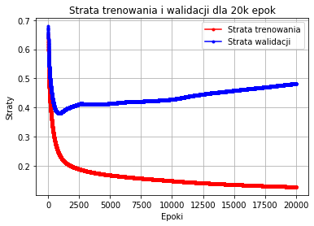

```python
#run_hist_1.history.keys()

plt.plot(run_hist_1.history["loss"],'r', marker='.', label="Strata trenowania")
plt.plot(run_hist_1.history["val_loss"],'b', marker='.', label="Strata walidacji")
plt.title("Strata trenowania i walidacji dla 20k epok")
plt.legend()
plt.xlabel('Epoki'),
plt.ylabel('Straty')
plt.grid()
```

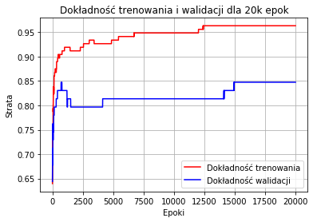

```python
plt.plot(run_hist_1.history["accuracy"],'r', label="Dokładność trenowania")
plt.plot(run_hist_1.history["val_accuracy"],'b', label="Dokładność walidacji")
plt.title("Dokładność trenowania i walidacji dla 20k epok")
plt.legend()
plt.xlabel('Epoki'), plt.ylabel('Strata')
plt.grid()
```

[figure not shown]

```python
plt.xlim(0, 1250)
plt.plot(run_hist_1.history["loss"],'r', marker='.', label="Strata trenowania")
plt.plot(run_hist_1.history["val_loss"],'b', marker='.', label="Strata walidacji")
plt.title("Strata trenowania i walidacji dla 1250 epok")
plt.legend()
plt.xlabel('Epoki'),
plt.ylabel('Straty')
plt.grid()
```

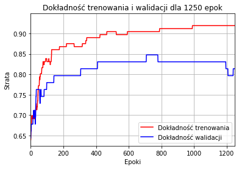

```python
plt.xlim(0, 1250)
plt.plot(run_hist_1.history["accuracy"],'r', label="Dokładność trenowania")
plt.plot(run_hist_1.history["val_accuracy"],'b', label="Dokładność walidacji")
plt.title("Dokładność trenowania i walidacji dla 1250 epok")
plt.legend()
plt.xlabel('Epoki'), plt.ylabel('Strata')
plt.grid()
```

### Student task 1:

- Learn more about [Dense](https://keras.io/layers/core/) layer, available [activation function](https://keras.io/activations/) and [optimizers](https://keras.io/optimizers/),

#### Czym są funkcje aktywacji i dlaczego musimy z nich korzystać?

Warstwa Dense bez funkcji aktywacji takiej jak funkcja relu (zwana również funkcją nieliniową) składałaby się z dwóch operacji liniowych — iloczynu skalarnego i dodawania:

output = dot(W, input) + b

W celu uzyskania dostępu do o wiele bogatszej przestrzeni hipotez i skorzystania z możliwości oferowanych przez głębokie reprezentacje danych potrzebujemy nieliniowości zapewnianej przez funkcję aktywacji. Funkcją najczęściej stosowaną w uczeniu głębokim tego typu jest funkcja relu, ale istnieje wiele innych funkcji o podobnie dziwnych nazwach: prelu, elu itd.

#### Wnioski z poprzedniego przykładu (i książki Deep Learninc Helion)

(WAŻNE) W przypadku problemu klasyfikacji binarnej (dwie klasy wyjściowe) na końcu sieci powinna znajdować się warstwa Dense z jedną jednostką i funkcją aktywacji sigmoid — wartości wyjściowe generowane przez sieć powinny być skalarami znajdującymi się w zakresie od 0 do 1 (powinny określać prawdopodobieństwo).

(WAŻNE) Sieci neuronowe wraz z coraz lepszym poznawaniem danych treningowych zaczynają się nadmiernie do nich dopasowywać, co prowadzi do pogorszenia rezultatów przetwarzania nowych danych. Musisz stale monitorować wydajność sieci podczas przetwarzania danych niewchodzących w skład zbioru treningowego

### Student task 1:

- Build neural network with more then 4 layers having different activation function in each layer. Train it and visual the results.

```python
#Krok 1 - wczytujemy ulr
url = "https://archive.ics.uci.edu/ml/machine-learning-databases/parkinsons/parkinsons.data"

#Krok 2 - zapisujemy nazwy atrybutów do tablicy
names = ["name","MDVP:Fo(Hz)","MDVP:Fhi(Hz)","MDVP:Flo(Hz)","MDVP:Jitter(%)","MDVP:Jitter(Abs)","MDVP:RAP","MDVP:PPQ",
         "Jitter:DDP","MDVP:Shimmer","MDVP:Shimmer(dB)","Shimmer:APQ3","Shimmer:APQ5","MDVP:APQ","Shimmer:DDA",
         "NHR","HNR","status","RPDE","DFA","spread1","spread2","D2","PPE"]

#Krok 3 - załadowanie danych CSV za pomocą pandas.read_csv(link z danymi, tablica nazw atrybutów)
parkinson_df = pd.read_csv(url, names=names)

#Krok 4 - załadowanie Pandas Dataframe do tablic numpy. Data - zbiór cech, target - szukana cecha
data = parkinson_df.loc[1:,["MDVP:Fo(Hz)","MDVP:Fhi(Hz)","MDVP:Flo(Hz)","MDVP:Jitter(%)","MDVP:Jitter(Abs)","MDVP:RAP","MDVP:PPQ",
         "Jitter:DDP","MDVP:Shimmer","MDVP:Shimmer(dB)","Shimmer:APQ3","Shimmer:APQ5","MDVP:APQ","Shimmer:DDA",
         "NHR","HNR","RPDE","DFA","spread1","spread2","D2","PPE"]].values.astype(np.float)
target = parkinson_df.loc[1:, ['status']].values.astype(np.float)

#Krok 5 - standaryzacja danych
data = StandardScaler().fit_transform(data)

#Krok 6 - podział na zbiory testujące i uczące
data_train, data_test, target_train, target_test = \
train_test_split(data, target, test_size=0.3, random_state=545)

#Krok 7 - utworzenie modelu
neural_model = Sequential([
    Dense(22, input_shape=(22,), activation="relu"),
    Dense(16, activation="softmax"),
    Dense(8, activation="elu"),
    Dense(4, activation="tanh"),
    Dense(1, activation="sigmoid")
])

#Po uruchomieniu wbudowanej funkcji summary, możemy zobaczyć, jak wygląda
#architektura stworzonej przez nas sieci.
neural_model.summary()

#Krok 8 - konfiguracja procesu uczenia się
neural_model.compile(SGD(lr = .003), "binary_crossentropy", metrics=["accuracy"])

#Krok 9 - ustaw dany random seed
np.random.seed(0)

#Krok 10 - proces uczenia modelu
#    Zwróć uwagę na to, że wywołanie metody model.fit() zwraca obiekt History (historia).
#    Obiekt ten mieści element o nazwie history, który jest słownikiem zawierającym dane
#    dotyczące przebiegu procesu trenowania.
run_hist_1 = neural_model.fit(data_train, target_train, epochs=2000,\
                              validation_data=(data_test, target_test), \
                              verbose=0, shuffle=False)
#Trenowanie...
print("Training neural network...\n")

#Krok 11 - Dokładność dla danych trenujących
print('Accuracy over training data is ', \
      accuracy_score(target_train, neural_model.predict_classes(data_train)))

#Krok 12 - Dokładność dla danych testujących
print('Accuracy over testing data is ', \
      accuracy_score(target_test, neural_model.predict_classes(data_test)))

#Krok 13 - Macierz konfuzji
conf_matrix = confusion_matrix(target_test, neural_model.predict_classes(data_test))
print(conf_matrix)
```

```
Model: "sequential_46"
_________________________________________________________________
Layer (type)                 Output Shape              Param #
=================================================================
dense_136 (Dense)            (None, 22)                506
_________________________________________________________________
dense_137 (Dense)            (None, 16)                368
_________________________________________________________________
dense_138 (Dense)            (None, 8)                 136
_________________________________________________________________
dense_139 (Dense)            (None, 4)                 36
_________________________________________________________________
dense_140 (Dense)            (None, 1)                 5
=================================================================
Total params: 1,051
Trainable params: 1,051
Non-trainable params: 0
_________________________________________________________________
Training neural network...

Accuracy over training data is  0.9411764705882353
Accuracy over testing data is  0.864406779661017
[[ 7  8]
 [ 0 44]]
```

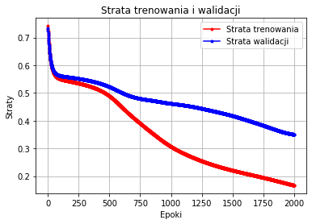

```python
plt.plot(run_hist_1.history["loss"],'r', marker='.', label="Strata trenowania")
plt.plot(run_hist_1.history["val_loss"],'b', marker='.', label="Strata walidacji")
plt.title("Strata trenowania i walidacji")
plt.legend()
plt.xlabel('Epoki'),
plt.ylabel('Straty')
plt.grid()
```

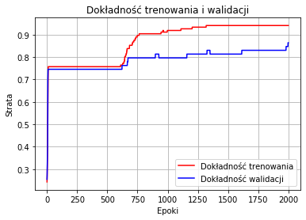

```python
plt.plot(run_hist_1.history["accuracy"],'r', label="Dokładność trenowania")
plt.plot(run_hist_1.history["val_accuracy"],'b', label="Dokładność walidacji")
plt.title("Dokładność trenowania i walidacji")
plt.legend()
plt.xlabel('Epoki'), plt.ylabel('Strata')
plt.grid()
```

### Budowa sieci neuronowej przy użyciu Keras oraz modelu Sequential z Dropout

```python
#Model może zostać zdefiniowany na dwa sposoby: przy użyciu klasy Sequential (tylko
#w przypadku liniowych stosów warstw, czyli obecnie najpopularniejszej architektury
#sieci) lub funkcjonalnego interfejsu API (w przypadku skierowanych acyklicznych grafów
#warstw — interfejs ten pozwala na tworzenie sieci o dowolnej architekturze).

# Kilka słów do dropout:
# Porzucanie (ang. droput) jest jedną z najbardziej skutecznych i najpopularniejszych
# technik regularyzacji sieci neuronowych. Opracował ją Goeffrey Hinton podczas współ-
# pracy ze swoimi studentami na Uniwersytecie w Toronto. Technika ta polega na loso-
# wym wybieraniu pewnej liczby cech wyjściowych warstwy podczas trenowania (wartości
# tych warstw są zastępowane zerami). Załóżmy, że w czasie trenowania warstwa sieci
# normalnie zwraca wektor [0.2, 0.5, 1.3, 0.8, 1.1]. Po przeprowadzeniu operacji
# porzucania w wektorze tym (w losowo wybranych miejscach) pojawią się zera i uzyska
# on np. formę [0, 0.5, 1.3, 0, 1.1]. Ułamek określający część wyzerowanych cech
# nazywamy współczynnikiem porzucania (ang. dropout rate). Zwykle parametr ten
# przyjmuje wartość znajdującą się w przedziale od 0,2 do 0,5. Podczas testowania żadne
# jednostki nie są porzucane — wartości wyjściowe warstwy sieci są skalowane o współ-
# czynnik równy współczynnikowi porzucania. Równoważy to aktywność większej liczby
# jednostek podczas testowania niż trenowania.

# Technika ta może wydawać się dziwna i chaotyczna. Jak ma pomóc w zmniejszeniu
# nadmiernego dopasowania? Hinton tworząc ją, inspirował się mechanizmami zapobie-
# gającymi nadużyciom stosowanym przez banki. Stwierdził: „Pewnego dnia, gdy posze-
# dłem do banku, zauważyłem, że osoby w okienkach często zmieniają swoje miejsca;
# pracownicy banku nie potrafili powiedzieć, dlaczego to robią, ale doszedłem do wnio-
# sku, że przy takiej rotacji wyłudzenie pieniędzy z banku wymagałoby współpracy wielu
# pracowników; wówczas zdałem sobie sprawę, że losowe usuwanie różnych podzbiorów
# neuronów podczas przetwarzania każdego przykładu zapobiegnie konspiracji i zredu-
# kuje nadmierne dopasowanie”. Główną ideą tej techniki jest wprowadzenie szumu do
# wartości wyjściowych warstwy w celu pozbycia się nieznaczących wzorców (Hinton
# określił je mianem „konspiracji”) — wprowadzenie szumu zapobiega zapamiętywaniu
# takich wzorców przez sieć.

#Krok 1 - utworzenie modelu
neural_network_d = Sequential()
neural_network_d.add(Dense(2, activation='relu', input_shape=(22,)))
neural_network_d.add(Dropout(0.1))
#neural_network_d.add(Dense(2, activation='relu'))
#neural_network_d.add(Dropout(0.1))
neural_network_d.add(Dense(1, activation='sigmoid'))

#Po uruchomieniu wbudowanej funkcji summary, możemy zobaczyć, jak wygląda
#architektura stworzonej przez nas sieci.
neural_network_d.summary()

#Krok 2 - konfiguracja procesu uczenia się
neural_network_d.compile(SGD(lr = .003), "binary_crossentropy", metrics=["accuracy"])

#Krok 3 - proces uczenia modelu
#    Zwróć uwagę na to, że wywołanie metody model.fit() zwraca obiekt History (historia).
#    Obiekt ten mieści element o nazwie history, który jest słownikiem zawierającym dane
#    dotyczące przebiegu procesu trenowania.
run_hist_2 = neural_network_d.fit(data_train, target_train, epochs=4000, \
                                  validation_data=(data_test, target_test), \
                                  verbose=False, shuffle=False)

#Trenowanie...
print("Training neural network w dropouts..\n")

#Krok 4 - Dokładność dla danych trenujących
print('Accuracy over training data is ', accuracy_score(target_train, neural_network_d.predict_classes(data_train)))

#Krok 5 - Dokładność dla danych testujących
print('Accuracy over testing data is ', accuracy_score(target_test, neural_network_d.predict_classes(data_test)))
```

```
Model: "sequential_48"
_________________________________________________________________
Layer (type)                 Output Shape              Param #
=================================================================
dense_143 (Dense)            (None, 2)                 46
_________________________________________________________________
dropout_10 (Dropout)         (None, 2)                 0
_________________________________________________________________
dense_144 (Dense)            (None, 1)                 3
=================================================================
Total params: 49
Trainable params: 49
Non-trainable params: 0
_________________________________________________________________
Training neural network w dropouts..

Accuracy over training data is  0.9191176470588235
Accuracy over testing data is  0.7966101694915254
```

[figure not shown]

```python
plt.plot(run_hist_2.history["loss"],'r', marker='.', label="Strata trenowania")
plt.plot(run_hist_2.history["val_loss"],'b', marker='.', label="Strata walidacji")
plt.title("Dokładność trenowania i walidacji z porzucaniem")
plt.legend()
plt.xlabel('Epoki'),
plt.ylabel('Straty')
plt.grid()
```

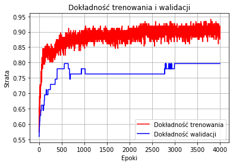

```python
plt.plot(run_hist_2.history["accuracy"],'r', label="Dokładność trenowania")
plt.plot(run_hist_2.history["val_accuracy"],'b', label="Dokładność walidacji")
plt.title("Dokładność trenowania i walidacji")
plt.legend()
plt.xlabel('Epoki'), plt.ylabel('Strata')
plt.grid()
```

*What is the benefits of using dropouts?*

Odp: (Opis dropout'a w komentarzu w kodzie) Unikamy nadmiernemy dopasowaniu modelu do danych uczących

### Student task 2

- Add dropouts to neural network from task 1 and compere the results.

```python
#Krok 1 - wczytujemy ulr
url = "https://archive.ics.uci.edu/ml/machine-learning-databases/parkinsons/parkinsons.data"

#Krok 2 - zapisujemy nazwy atrybutów do tablicy
names = ["name","MDVP:Fo(Hz)","MDVP:Fhi(Hz)","MDVP:Flo(Hz)","MDVP:Jitter(%)","MDVP:Jitter(Abs)","MDVP:RAP","MDVP:PPQ",
         "Jitter:DDP","MDVP:Shimmer","MDVP:Shimmer(dB)","Shimmer:APQ3","Shimmer:APQ5","MDVP:APQ","Shimmer:DDA",
         "NHR","HNR","status","RPDE","DFA","spread1","spread2","D2","PPE"]

#Krok 3 - załadowanie danych CSV za pomocą pandas.read_csv(link z danymi, tablica nazw atrybutów)
parkinson_df = pd.read_csv(url, names=names)

#Krok 4 - załadowanie Pandas Dataframe do tablic numpy. Data - zbiór cech, target - szukana cecha
data = parkinson_df.loc[1:,["MDVP:Fo(Hz)","MDVP:Fhi(Hz)","MDVP:Flo(Hz)","MDVP:Jitter(%)","MDVP:Jitter(Abs)","MDVP:RAP","MDVP:PPQ",
         "Jitter:DDP","MDVP:Shimmer","MDVP:Shimmer(dB)","Shimmer:APQ3","Shimmer:APQ5","MDVP:APQ","Shimmer:DDA",
         "NHR","HNR","RPDE","DFA","spread1","spread2","D2","PPE"]].values.astype(np.float)
target = parkinson_df.loc[1:, ['status']].values.astype(np.float)

#Krok 5 - standaryzacja danych
data = StandardScaler().fit_transform(data)

#Krok 6 - podział na zbiory testujące i uczące
data_train, data_test, target_train, target_test = \
train_test_split(data, target, test_size=0.3, random_state=545)

#Krok 7 - utworzenie modelu
neural_model = Sequential([
    Dense(22, input_shape=(22,), activation="relu"),
    Dropout(0.1),
    Dense(8, activation="elu"),
    Dropout(0.5),
    Dense(1, activation="sigmoid")
])

#Po uruchomieniu wbudowanej funkcji summary, możemy zobaczyć, jak wygląda
#architektura stworzonej przez nas sieci.
neural_model.summary()

#Krok 8 - konfiguracja procesu uczenia się
neural_model.compile(SGD(lr = .003), "binary_crossentropy", metrics=["accuracy"])

#Krok 9 - ustaw dany random seed
np.random.seed(0)

#Krok 10 - proces uczenia modelu
#    Zwróć uwagę na to, że wywołanie metody model.fit() zwraca obiekt History (historia).
#    Obiekt ten mieści element o nazwie history, który jest słownikiem zawierającym dane
#    dotyczące przebiegu procesu trenowania.
run_hist_5 = neural_model.fit(data_train, target_train, epochs=2000,\
                              validation_data=(data_test, target_test), \
                              verbose=0, shuffle=False)
#Trenowanie...
print("Training neural network...\n")

#Krok 11 - Dokładność dla danych trenujących
print('Accuracy over training data is ', \
      accuracy_score(target_train, neural_model.predict_classes(data_train)))

#Krok 12 - Dokładność dla danych testujących
print('Accuracy over testing data is ', \
      accuracy_score(target_test, neural_model.predict_classes(data_test)))

#Krok 13 - Macierz konfuzji
conf_matrix = confusion_matrix(target_test, neural_model.predict_classes(data_test))
print(conf_matrix)
```

```
Model: "sequential_50"
_________________________________________________________________
Layer (type)                 Output Shape              Param #
=================================================================
dense_147 (Dense)            (None, 22)                506
_________________________________________________________________
dropout_11 (Dropout)         (None, 22)                0
_________________________________________________________________
dense_148 (Dense)            (None, 8)                 184
_________________________________________________________________
dropout_12 (Dropout)         (None, 8)                 0
_________________________________________________________________
dense_149 (Dense)            (None, 1)                 9
=================================================================
Total params: 699
Trainable params: 699
Non-trainable params: 0
_________________________________________________________________
Training neural network...

Accuracy over training data is  0.9632352941176471
Accuracy over testing data is  0.847457627118644
[[ 7  8]
 [ 1 43]]
```

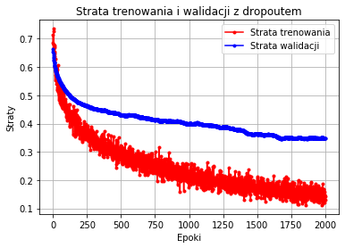

```python
plt.plot(run_hist_5.history["loss"],'r', marker='.', label="Strata trenowania")
plt.plot(run_hist_5.history["val_loss"],'b', marker='.', label="Strata walidacji")
plt.title("Strata trenowania i walidacji z dropoutem")
plt.legend()
plt.xlabel('Epoki'),
plt.ylabel('Straty')
plt.grid()
```

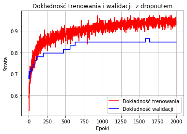

```python
plt.plot(run_hist_5.history["accuracy"],'r', label="Dokładność trenowania")
plt.plot(run_hist_5.history["val_accuracy"],'b', label="Dokładność walidacji")
plt.title("Dokładność trenowania i walidacji  z dropoutem")
plt.legend()
plt.xlabel('Epoki'), plt.ylabel('Strata')
plt.grid()
```

# Sieć neuronowa do wieloklasowej klasyfikacji danych MNIST

Zbiór danych MNIST jest dołączony do pakietu Keras w formie czterech tablic Numpy. Jest uznawany przez środowisko analityków za zbiór klasyczny. Istnieje on tak długo, jak długa jest historia uczenia maszynowego. Zbiór ten zawiera 60 000 obrazów treningowych oraz 10 000 obrazów testowych. Został utworzony przez Narodowy Instytut Standaryzacji i Technologii (NIST) w latach 80. ubiegłego wieku.

```python
from keras.datasets import mnist
(x_train, y_train), (x_test, y_test) = mnist.load_data()
```

```python
images_train =  []
for image_train in x_train:
    images_train.append(image_train.flatten())

images_test = []

for image_test in x_test:
    images_test.append(image_test.flatten())

images_train = np.array(images_train)
images_test = np.array(images_test)

from keras.utils import normalize
images_train = normalize(images_train)
images_test = normalize(images_test)

from keras.utils.np_utils import to_categorical

y_train_categorical = to_categorical(y_train)
y_test_categorical = to_categorical(y_test)
```

```python
neural_network_mnist = Sequential()
neural_network_mnist.add(Dense(50, activation='relu', input_shape=(784,)))
neural_network_mnist.add(Dense(10, activation='softmax'))

neural_network_mnist.summary()

sgd = SGD(lr=0.1, decay=1e-6, momentum=0.9)
neural_network_mnist.compile(optimizer=sgd, loss="categorical_crossentropy", \
                             metrics=["accuracy"])

run_hist_3 = neural_network_mnist.fit(images_train, y_train_categorical, epochs=20, \
                                  validation_data=(images_test, y_test_categorical), \
                                  verbose=0, shuffle=False)
```

```
Model: "sequential_52"
_________________________________________________________________
Layer (type)                 Output Shape              Param #
=================================================================
dense_152 (Dense)            (None, 50)                39250
_________________________________________________________________
dense_153 (Dense)            (None, 10)                510
=================================================================
Total params: 39,760
Trainable params: 39,760
Non-trainable params: 0
_________________________________________________________________
```

### Zapisywanie sieci neuronowej

```python
neural_network_mnist.save('mnist-model.h5')
```

### Visualizing training

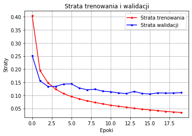

```python
plt.plot(run_hist_3.history["loss"],'r', marker='.', label="Strata trenowania")
plt.plot(run_hist_3.history["val_loss"],'b', marker='.', label="Strata walidacji")
plt.title("Strata trenowania i walidacji")
plt.legend()
plt.xlabel('Epoki'),
plt.ylabel('Straty')
plt.grid()
```

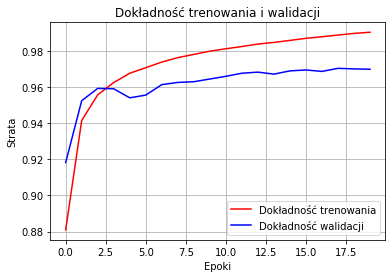

```python
plt.plot(run_hist_3.history["accuracy"],'r', label="Dokładność trenowania")
plt.plot(run_hist_3.history["val_accuracy"],'b', label="Dokładność walidacji")
plt.title("Dokładność trenowania i walidacji")
plt.legend()
plt.xlabel('Epoki'), plt.ylabel('Strata')
plt.grid()
```

### Wczytywanie zapisanego modelu

```python
from keras.models import load_model
model = load_model('mnist-model.h5')
```

```python
print("Model evaluation [loss, accu]: ", model.evaluate(images_test, y_test_categorical))
```

```
Model evaluation [loss, accu]:  [0.11021431843200116, 0.9697999954223633]
```

### Usage of a trained neural model

```
Neural netowrk predicts:
[[5.0373893e-12 8.1811518e-09 4.2378621e-09 9.9995267e-01 3.0635932e-09
  4.7275829e-05 1.5244042e-13 6.3852855e-12 1.2984700e-08 1.3133301e-08]]

Neural network recognized image as: 3
```

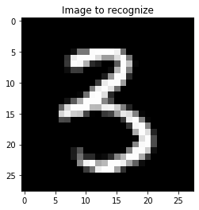

```python
id = 5000

print("Neural netowrk predicts:")
print(model.predict(images_test[id,:].reshape(-1,784)))

plt.imshow(images_test[id,:].reshape(28,28), cmap=plt.get_cmap("gray"))
plt.title('Image to recognize')

print("\nNeural network recognized image as:", np.argmax(model.predict(images_test[id,:].reshape(-1,784))))
```

### Student task 3

Build **two** neural network based regression model to predict "Boston housing" price. One without dropouts and one with droputs. Remember to use aprioprate loss function and activation in output layer. Evaluate model and visual learning process. Experiments with different network architecture and optimization parameters. Use data from Keras library.

```python
from keras.datasets import boston_housing
(X_Train, y_train), (X_Test, y_test) = boston_housing.load_data()

#KROK 01 - sprawdź dane
train_data.shape
```

```
(404, 13)
```

```python
test_data.shape
```

```
(102, 13)
```

```python
#KROK 02 - standaryzacja danych
scaler = StandardScaler()
scaler.fit(X_train)
X_train_scaled = scaler.transform(X_Train)
X_test_scaled = scaler.transform(X_Test)
```

```python
#KROK 03 - utwórz model, wersja pierwsza - bez dropoutów
mod_01 = Sequential()
mod_01.add(Dense(64, activation='relu', input_shape=[X_train.shape[1]]))
mod_01.add(Dense(32, activation='relu'))
mod_01.add(Dense(1))

#(WAŻNE)Sieć kończy się pojedynczą jednostką bez funkcji aktywacji (jest to warstwa liniowa).
#To typowe rozwiązanie stosowane w regresji skalarnej (regresji, w której próbuje się
#przewidzieć jedną wartość o charakterze ciągłym). Zastosowanie funkcji aktywacji
#ograniczyłoby zakres wartości wyjściowych możliwych do wygenerowania. Gdybyśmy
#zastosowali w ostatniej warstwie tej sieci funkcję aktywacji sigmoid, to sieć mogłaby
#generować tylko wartości znajdujące się w zakresie od 0 do 1. W praktyce zastosowaliśmy
#ostatnią warstwę o charakterze liniowym, a więc możemy przewidywać dowolne wartości.

#KROK 04 - kompilacja modelu
mod_01.compile(optimizer='rmsprop', loss='mse', metrics=['mae'])
#(WAŻNE)Zwróć uwagę na to, że sieć jest kompilowana z funkcją straty mse (średniego błędu
#kwadratowego). Funkcja ta oblicza kwadrat różnicy między wartościami przewidywanymi przez
#sieć i wartościami docelowymi. Ta funkcja straty jest często używana w czasie
#rozwiązywania problemów regresji. Podczas trenowania monitorowana jest nowa metryka:
#średni błąd bezwzględny (mae). Jest to bezwzględna wartość różnicy między wartościami przewidywanymi przez sieć
#a wartościami docelowymi. Średnia wartość błędu bezwzględnego o wartości równej
#np. 0,5 w przypadku tego problemu oznacza, że przewidywane ceny średnio odbiegają
#od wartości docelowych o 500 dolarów

#KROK 05 - nauka modelu
history_01 = mod_01.fit(X_train_scaled, y_train, epochs=200, verbose=1, validation_data=(X_test_scaled, y_test))
```

```
Train on 404 samples, validate on 102 samples
```

```python
mod_01.evaluate(X_test_scaled, y_test)
#Pierwsza wartość - MSE, druga wartość - MAE (Mean Absolute Error)
```

```
[13.522924685010723, 2.394848585128784]
```

[figure not shown]

```python
plt.plot(history_01.history["loss"],'r', label="Strata trenowania")
plt.plot(history_01.history["val_loss"], label="Strata walidacji")
plt.title("Strata trenowania i walidacji z dropoutem")
plt.legend()
plt.xlabel('Epoki'),
plt.ylabel('Straty')
plt.grid()
```

```python
#WNIOSEK - Można przerwać wcześniej epokę - gdzieś około 25tej iteracji
```

[figure not shown]

```python
plt.xlim(0, 25)
plt.plot(history_01.history["loss"],'r', label="Strata trenowania")
plt.plot(history_01.history["val_loss"], label="Strata walidacji")
plt.title("Strata trenowania i walidacji z dropoutem")
plt.legend()
plt.xlabel('Epoki'),
plt.ylabel('Straty')
plt.grid()
```

```python
#WNIOSEK - Przy epoce 15 otrzymamy najlepiej nauczony model
```

```python
#MODEL Z DROPOUT'AMI

#KROK 03 - utwórz model, wersja pierwsza - bez dropoutów
mod_02 = Sequential()
mod_02.add(Dense(64, activation='relu', input_shape=[X_train.shape[1]]))
mod_02.add(Dropout(0.1))
mod_02.add(Dense(32, activation='relu'))
mod_02.add(Dropout(0.3))
mod_02.add(Dense(1))

#(WAŻNE)Sieć kończy się pojedynczą jednostką bez funkcji aktywacji (jest to warstwa liniowa).
#To typowe rozwiązanie stosowane w regresji skalarnej (regresji, w której próbuje się
#przewidzieć jedną wartość o charakterze ciągłym). Zastosowanie funkcji aktywacji
#ograniczyłoby zakres wartości wyjściowych możliwych do wygenerowania. Gdybyśmy
#zastosowali w ostatniej warstwie tej sieci funkcję aktywacji sigmoid, to sieć mogłaby
#generować tylko wartości znajdujące się w zakresie od 0 do 1. W praktyce zastosowaliśmy
#ostatnią warstwę o charakterze liniowym, a więc możemy przewidywać dowolne wartości.

#KROK 04 - kompilacja modelu
mod_02.compile(optimizer='rmsprop', loss='mse', metrics=['mae'])
#(WAŻNE)Zwróć uwagę na to, że sieć jest kompilowana z funkcją straty mse (średniego błędu
#kwadratowego). Funkcja ta oblicza kwadrat różnicy między wartościami przewidywanymi przez
#sieć i wartościami docelowymi. Ta funkcja straty jest często używana w czasie
#rozwiązywania problemów regresji. Podczas trenowania monitorowana jest nowa metryka:
#średni błąd bezwzględny (mae). Jest to bezwzględna wartość różnicy między wartościami przewidywanymi przez sieć
#a wartościami docelowymi. Średnia wartość błędu bezwzględnego o wartości równej
#np. 0,5 w przypadku tego problemu oznacza, że przewidywane ceny średnio odbiegają
#od wartości docelowych o 500 dolarów

#KROK 05 - nauka modelu
history_2 = mod_02.fit(X_train_scaled, y_train, epochs=250, verbose=1, validation_data=(X_test_scaled, y_test))
```

```
Train on 404 samples, validate on 102 samples
```

```python
mod_02.evaluate(X_test_scaled, y_test)
#Pierwsza wartość - MSE, druga wartość - MAE (Mean Absolute Error)
```

```
[19.555131351246555, 2.977130889892578]
```

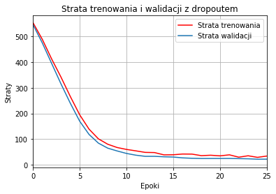

```python
plt.xlim(0, 25)
plt.plot(history_2.history["loss"],'r', label="Strata trenowania")
plt.plot(history_2.history["val_loss"], label="Strata walidacji")
plt.title("Strata trenowania i walidacji z dropoutem")
plt.legend()
plt.xlabel('Epoki'),
plt.ylabel('Straty')
plt.grid()
```

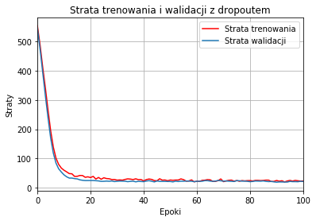

```python
#Poszerzam zakres
plt.xlim(0, 100)
plt.plot(history_2.history["loss"],'r', label="Strata trenowania")
plt.plot(history_2.history["val_loss"], label="Strata walidacji")
plt.title("Strata trenowania i walidacji z dropoutem")
plt.legend()
plt.xlabel('Epoki'),
plt.ylabel('Straty')
plt.grid()
```

[output not shown]

[figure not shown]

```python
###EKSPERYMENTY
#KROK 03 - utwórz model, wersja pierwsza - bez dropoutów
mod_03 = Sequential()
mod_03.add(Dense(64, activation='relu', input_shape=[X_train.shape[1]]))
mod_03.add(Dense(32, activation='tanh'))
mod_03.add(Dense(1))

#KROK 04 - kompilacja modelu
mod_03.compile(optimizer='rmsprop', loss='mse', metrics=['mae'])

#KROK 05 - nauka modelu
history_03 = mod_03.fit(X_train_scaled, y_train, epochs=50, verbose=0, validation_data=(X_test_scaled, y_test))

plt.plot(history_03.history["loss"],'r', label="Strata trenowania")
plt.plot(history_03.history["val_loss"], label="Strata walidacji")
plt.title("Strata trenowania i walidacji z dropoutem")
plt.legend()
plt.xlabel('Epoki'),
plt.ylabel('Straty')
plt.grid()

mod_03.evaluate(X_test_scaled, y_test)
#Pierwsza wartość - MSE, druga wartość - MAE (Mean Absolute Error)
```

```
[123.78138104607078, 8.334908485412598]
```

[figure not shown]

```python
###EKSPERYMENTY
#KROK 03 - utwórz model, wersja pierwsza - bez dropoutów
mod_04 = Sequential()
mod_04.add(Dense(32, activation='tanh', input_shape=[X_train.shape[1]]))
mod_04.add(Dense(18, activation='tanh'))
mod_04.add(Dense(1))

#KROK 04 - kompilacja modelu
mod_04.compile(optimizer='rmsprop', loss='mse', metrics=['mae'])

#KROK 05 - nauka modelu
history_04 = mod_04.fit(X_train_scaled, y_train, epochs=50, verbose=0, validation_data=(X_test_scaled, y_test))

plt.plot(history_04.history["loss"],'r', label="Strata trenowania")
plt.plot(history_04.history["val_loss"], label="Strata walidacji")
plt.title("Strata trenowania i walidacji z dropoutem")
plt.legend()
plt.xlabel('Epoki'),
plt.ylabel('Straty')
plt.grid()

mod_04.evaluate(X_test_scaled, y_test)
#Pierwsza wartość - MSE, druga wartość - MAE (Mean Absolute Error)
```

```
[12.695549983604282, 2.4776620864868164]
```

[figure not shown]

```python
###EKSPERYMENTY
#KROK 03 - utwórz model, wersja pierwsza - bez dropoutów
mod_05 = Sequential()
mod_05.add(Dense(32, activation='tanh', input_shape=[X_train.shape[1]]))
mod_05.add(Dense(18, activation='tanh'))
mod_05.add(Dense(18, activation='relu'))
mod_05.add(Dense(1))

#KROK 04 - kompilacja modelu
mod_05.compile(optimizer='rmsprop', loss='mse', metrics=['mae'])

#KROK 05 - nauka modelu
history_05 = mod_05.fit(X_train_scaled, y_train, epochs=500, verbose=0, validation_data=(X_test_scaled, y_test))

plt.plot(history_05.history["loss"],'r', label="Strata trenowania")
plt.plot(history_05.history["val_loss"], label="Strata walidacji")
plt.title("Strata trenowania i walidacji z dropoutem")
plt.legend()
plt.xlabel('Epoki'),
plt.ylabel('Straty')
plt.grid()

mod_05.evaluate(X_test_scaled, y_test)
#Pierwsza wartość - MSE, druga wartość - MAE (Mean Absolute Error)
```